# MEEF PSA 2020-2021

## Python introduction

## Why should I learn python ?

- Because it's *cool* and because the logo if *fun*
- Because it's free and available for all platforms
- Because it's an high level language, which can be read easily in english, and without use of strange syntax

```python
import random
def choose_color():
    colors=['red','green','blue']
    return random.choice(colors)

my_color=choose_color()
print(my_color)
```

```
green
```

- Because it's an interpreted language which can be launched in interactive mode
- Because we can do science with it (numerous libraries)
- Because it's now a very common standard

## Why should I learn python ? (cont.)

- Because *I* have to !

Extraits de programmes (sorry, in french !)

- Seconde, sciences numériques

[figure not shown]

- Seconde, physique chimie

[figure not shown]

- Première, enseignement scientifique

[figure not shown]

## Where and how to use python ? 1/2

### Through a notebook interface on a cloud

Pros :

- nothing to install
- ease of use
- everything on the cloud
- web-based tool, meaning not at all platform dependent
- no matter about the updates

Cons :

- unavailable offline
- difficult to interact with local hardware

Where ?

- Here at university : http://jupy.physique.univ-paris-diderot.fr
- Elsewhere, e.g. https://notebooks.ai/

## Where and how to use python ? 2/2

### On a local machine

Pros :

- always available whatever the network is
- you manage the version
- interaction with hardware possible

Cons :

- have to do the install / updates
- not available in a cloud

What version :

- Python 3 (python 2 won't be maintained in few weeks)
- You may install `spyder` or `anaconda` (which comes with `spyder`, `iPython`, `SciPy`…)

## Very brief introduction of simple use of interactive mode

Language reference : https://docs.python.org/3/

### Make a simple computation

```python
1+2+3
```

```
6
```

But…

```python
sin(pi/2)
```

```
---------------------------------------------------------------------------
NameError                                 Traceback (most recent call last)
<ipython-input-3-7ec80c2057e2> in <module>()
----> 1 sin(pi/2)

NameError: name 'sin' is not defined
```

You need to use the `math` module :

```python
import math
math.sin(math.pi/2)
```

```
1.0
```

If you don't want to write each time `math.` at begining :

```python
import math as m
m.sin(m.pi/2)
```

```
1.0
```

or (dangerous way because some modules may have same variable/function names)

```python
# would be better to avoid this method
# please note that you can add a comment adding a dash at the beg of a line
from math import *
sin(pi/2)
```

```
1.0
```

### Some of available types

you can either let python choose default type of force one.

```python
a=2
print(a)
print(type(a))

b=12.34
print(b)
print(type(b))

c=float(3)
print(c)
print(type(c))

x=[0,1,2]
print(x)
print(type(x))

s="hi everybody !"
print(s)
print(type(s))
```

```
2
<class 'int'>
12.34
<class 'float'>
3.0
<class 'float'>
[0, 1, 2]
<class 'list'>
hi everybody !
<class 'str'>
```

### Operators

Their action is dependant of the type of the variable

```python
# addition with + for integers
a=1
b=2
print(a+b)

#concatenation with + for strings
s1="hello "
s2="world"
print(s1+s2)
```

```
3
hello world
```

Operator references : see https://docs.python.org/3/library/operator.html

### Lists, simple loop and controle structures

```python
a=[1,2,3,4]
b=[5,6,7,8]
print(a+b)
```

```
[1, 2, 3, 4, 5, 6, 7, 8]
```

```python
for x in a:
    print(x+2) # yes there is an indent here. Required for block of commands
```

```
3
4
5
6
```

You can create inhomogenous lists

```python
z=[0,True,3.4,"pi",[5,6]]
print(z)
print(type(z))
```

```
[0, True, 3.4, 'pi', [5, 6]]
<class 'list'>
```

To access a specific element, specify the index, begining at 0.

```python
print(z[0])
print(z[3])
print(z[-1]) # means last element
```

```
0
pi
[5, 6]
```

But you cannot actually do science computation with simple lists…

```python
x=[1,2,3]
print(2*x+3)
```

```
---------------------------------------------------------------------------
TypeError                                 Traceback (most recent call last)
<ipython-input-13-9a3f465da35e> in <module>()
      1 x=[1,2,3]
----> 2 print(2*x+3)

TypeError: can only concatenate list (not "int") to list
```

To learn more on the language, particularly on control structure (use of `for`, `if`, `while`, ...), please refer to the documentation.

https://docs.python.org/3/tutorial/controlflow.html?highlight=loop#

Example with the Eratosthene algorithm.

```python
def eratosthene(n):
    n += 1
    p = [0,0] + [i for i in range(2, n)]
    for i in range(2, n):
        if p[i] != 0:
            for j in range(i*2, n, i):
                p[j] = 0
    return [v for v in p if v!=0]

eratosthene(50)
```

```
[2, 3, 5, 7, 11, 13, 17, 19, 23, 29, 31, 37, 41, 43, 47]
```

## Scientific packages

Numpy

[figure not shown]

Scipy

[figure not shown]

MatplotLib

Reference : https://www.scipy.org/

Let's see some practical examples.

### Computation with (NumPy) arrays

Remember

```python
a=[1,2,3,4]
b=[5,6,7,8]
print(a+b)
```

```
[1, 2, 3, 4, 5, 6, 7, 8]
```

But…

```python
import numpy as np
x=np.array(a)
y=np.array(b)
z=np.add(x,y)
print(type(z))
print(z)
```

```
<class 'numpy.ndarray'>
[ 6  8 10 12]
```

Create and use a range array :

```python
theta=np.arange(-m.pi,m.pi,0.1)
y=np.cos(theta)
print(y)
```

```
[-1.         -0.99500417 -0.98006658 -0.95533649 -0.92106099 -0.87758256
 -0.82533561 -0.76484219 -0.69670671 -0.62160997 -0.54030231 -0.45359612
 -0.36235775 -0.26749883 -0.16996714 -0.0707372   0.02919952  0.12884449
  0.22720209  0.32328957  0.41614684  0.5048461   0.58850112  0.66627602
  0.73739372  0.80114362  0.85688875  0.90407214  0.94222234  0.97095817
  0.9899925   0.99913515  0.99829478  0.98747977  0.96679819  0.93645669
  0.89675842  0.84810003  0.79096771  0.7259323   0.65364362  0.57482395
  0.49026082  0.40079917  0.30733287  0.2107958   0.11215253  0.01238866
 -0.08749898 -0.18651237 -0.28366219 -0.37797774 -0.46851667 -0.55437434
 -0.63469288 -0.70866977 -0.77556588 -0.83471278 -0.88551952 -0.92747843
 -0.96017029 -0.98326844 -0.9965421 ]
```

Create an array between two floats with N values

```python
z=np.linspace(-2,10,25)
print(z)
```

```
[-2.  -1.5 -1.  -0.5  0.   0.5  1.   1.5  2.   2.5  3.   3.5  4.   4.5
  5.   5.5  6.   6.5  7.   7.5  8.   8.5  9.   9.5 10. ]
```

Create random array :

```python
flat_noise=np.random.random(50)
print(flat_noise)
```

```
[0.79335839 0.05547304 0.48083334 0.73277731 0.33022379 0.30885597
 0.04089844 0.85754228 0.70169917 0.47395227 0.15180327 0.3908999
 0.86080154 0.04865158 0.83195525 0.04184472 0.214995   0.69436615
 0.11182689 0.05746305 0.80655824 0.22062043 0.87732337 0.47205212
 0.35984012 0.29555541 0.55456105 0.91072916 0.13642833 0.50337858
 0.03966334 0.33159254 0.5957209  0.53362926 0.96232713 0.47999366
 0.27060102 0.94994417 0.42639559 0.54522448 0.34273654 0.53491233
 0.61329721 0.60287193 0.00986923 0.17984335 0.1649451  0.44220716
 0.00208814 0.37243283]
```

### Plots with MatplotLib

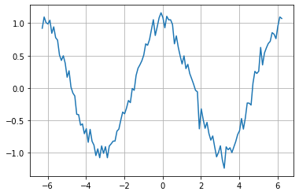

```python
import numpy as np
import matplotlib.pyplot as plt
import math as m
x=np.arange(-2*m.pi,2*m.pi,0.1)
y=np.cos(x)
y_noise=0.1*np.random.randn(y.size) # normal distribution of noise
plt.plot(x,y+y_noise)
plt.grid()
```

In order to interact with the graph (zoom, move, save figure), you have to run a specific MatplotLib command

```python
%matplotlib widget
```

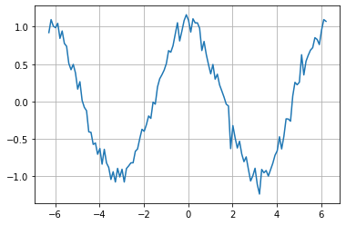

```python
# You have to try this in the notebook directly...
plt.plot(x,y+y_noise)
plt.grid()
```

### Fitting

#### Linear fit with SciPy

But you cannot get easily the error on fitted parameters.

```
(-1.8059004425056537, 2.789544675760098)
```

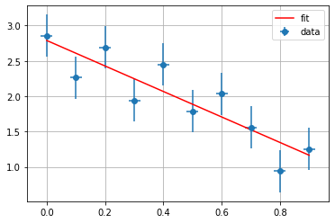

```python
from scipy import stats
x=np.arange(0,1,0.1)
dx=0.02
dy=0.3
y=-2*x+3+np.random.normal(0,dy,x.size)
r = stats.linregress(x,y)
mn=np.min(x)
mx=np.max(x)
x1=np.linspace(mn,mx,500)
y1=r.slope*x1+r.intercept
plt.errorbar(x,y,xerr=dx,yerr=dy,fmt='o',label='data')
plt.plot(x1,y1,'-r',label='fit')
plt.legend()
plt.grid()
print((r.slope,r.intercept))
```

#### Linear fit with fitutils

Caution : `fitutils` is not a standard tool but it is available on your prefered jupyter server. If you're looking for this module, you will find it on the `jupyter` server at `/home/libs/`.

This module is a (brand new) version of the `linfitxy` MatlabⓇ tool available at https://github.com/tjbtjbtjb/linfitxy. Because this python version is quite new, it may still include some issues…

Main advantage of that tool : it deals with both errors on `Y` axis *and* `X` axis, whereas most tools (all tools ?) don't.

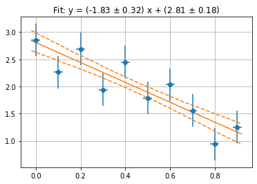

```python
import sys
import fitutils as fu
dx=np.ones(x.size)*dx
dy=np.ones(y.size)*dy
fu.linfitxy(x,y,dx,dy)
plt.grid()
```

#### Non linear fit

Can be done either with `polyfit` (for polynoms) or `curvefit` (whatever the function is). One should prefer this `curvefit` because on can easily get errors on fitted parameters. See below.

```python
def f1(x,a,b,c):
    return a*x**2+b*x+c

N=15
x_exp=np.random.random(N)*10-5   # Get random x between -5 and +5
y=f1(x_exp,-2,3,60)         # Compute y
dy=np.random.randn(N)*5         # Some noise
y_exp=y+dy                       # Let's assume those are experimental data

# Fitting with polyfit
p=np.polyfit(x_exp,y_exp,2)   # Fit with numpy.polyfit
print(p)

# Fitting with curvefit, try to fit a normal
from scipy import optimize
from scipy.stats import norm
def f2(x,m,s,n):
    return n*norm.pdf(x,m,s)

param,cov=optimize.curve_fit(f2,x_exp,y_exp,p0=[0,1,10],sigma=np.ones(N)*5)
err=np.zeros(np.size(param))
for i in range(np.size(param)):
    err[i]=m.sqrt(cov[i][i])
print(param,err)
```

```
[-1.88025615  2.61769821 59.97054824]
[  0.79691196   3.15539709 500.77476585] [ 0.20553487  0.23351125 28.11189504]
```

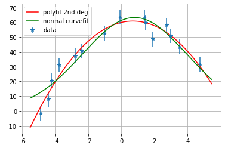

```python
plt.errorbar(x_exp,y_exp,yerr=5,fmt='*',label='data')
x=np.arange(-5.5,5.5,0.05)
plt.plot(x,f1(x,p[0],p[1],p[2]),'r',label='polyfit 2nd deg')
plt.plot(x,f2(x,param[0],param[1],param[2]),'g',label='normal curvefit')
plt.grid()
plt.legend()
```

### Now some basic statistics

```
1.0802972213925606 -3.004597207028447 -2.9593235598008825
```

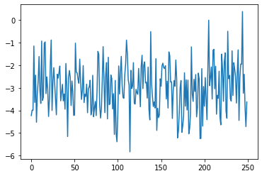

```python
import numpy as np
x=np.random.normal(-3,1,250)
plt.plot(x)
s=np.std(x)
m=np.mean(x)
m2=np.median(x)
print(s,m,m2)
```

### Histogramming

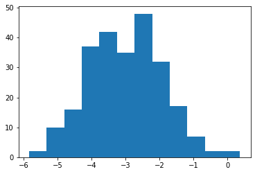

```python
histo,edges,z=plt.hist(x,12)
```

## Still various things in python…

### Read a text file

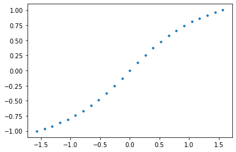

```python
import matplotlib.pyplot as plt
with open('file1.txt', 'r') as f:
    lines = f.readlines()
    x = [float(line.split()[0]) for line in lines]
    y = [float(line.split()[1]) for line in lines]
plt.plot(x ,y,'.')
plt.show()
```

### Interaction

*This has to be tested in a notebook, it does not work under slide mode*

```python
from ipywidgets import interact
import numpy as np
import matplotlib.pyplot as plt
import matplotlib.axes as ax
import math as m

def f(nx,ny,wx,wy,phi):
    t=np.linspace(0,m.pi*4,500)
    x=nx*np.cos(t*wx)
    y=ny*np.cos(t*wy+phi)
    plt.plot(x,y)
    plt.ylim((-2,2))
    plt.xlim((-2,2))
    plt.grid(True)

interact(f,nx=(0,2,0.1),ny=(0,2,0.1),wx=(0,6,0.5),wy=(0,6,0.5),phi=(-m.pi,m.pi,0.1))
```

```
<function __main__.f>
```

## Communication

Caution : should be launched locally, not in a notebook

```python
# Assume that arduino has the L/H Builtin LED program uploaded
import serial
s=serial.Serial('/dev/ttyACM0','9600') # One should change the path of the com port according to the actual machine
s.write(b'L')
s.write(b'H')
```

# And now ?

Let's play with python, and please refer to the documentation, tutorial, examples, read them, modify them.